# Milestone report word prediction app

K. Grimmerink

19-02-2017

## Overview

In this report the first findings and directions to develop a word prediction application are presented.The available dataset is explored and the steps and choices that are made are explained.

## Loading of the data

Three datasets are available, with Twitter, blogs and newsmessages on internet.

```r
con <- file("en_US.twitter.txt", "r")
twitter<-readLines(con)
close(con)
con <- file("en_US.blogs.txt", "r")
blogs<-readLines(con)
close(con)
con <- file("en_US.news.txt", "r")
news<-readLines(con)
close(con)
```

The twitter dataset has the most lines, with more than 2 million lines.These are the shortest messages.

```r
length(twitter)
```

```
## [1] 2360148
```

```r
length(blogs)
```

```
## [1] 899288
```

```r
length(news)
```

```
## [1] 77259
```

Using all the data would take to much processing time, that’s why I take a subset to train and test the data on. I take a 50th part of all the data.

```r
set.seed(1000)
id_twitter<-sample(1:length(twitter),size=length(twitter)/50,replace=FALSE)
twitter_train<-twitter[id_twitter]
twitter_test<-twitter[-id_twitter]
set.seed(2000)
id_blogs<-sample(1:length(blogs),size=length(blogs)/50,replace=FALSE)
blogs_train<-blogs[id_blogs]
blogs_test<-blogs[-id_blogs]
set.seed(3000)
id_news<-sample(1:length(news),size=length(news)/50,replace=FALSE)
news_train<-news[id_news]
news_test<-news[-id_news]
```

## Making and exploring n-grams

With the quanteda package the 3 trainingsets are combined in a corpus and tokenized. I added end-of-sentence marks and start-of-line marks in the data, so I can see the difference between the first words in a message, which have no connection to the words seen before in another message, and the first words of a sentence following another sentence in the same message, here there is a connection. In the tokenizing procedure, numbers, punctuation and symbols are removed.

Let’s first have a look at the words in the dataset. The number of identical words in the dataset is:

```
## [1] 85599
```

So there are over 85.000 unique words in the dataset. How many words do we need to cover 50% of all the words in the data, and how many for 80%?

```
## [1] 119
```

```
## [1] 2466
```

As we see in the plot below, the coverage percentage increases very fast up to 80%. So we don’t need so many words to have a good coverage of the complete set.

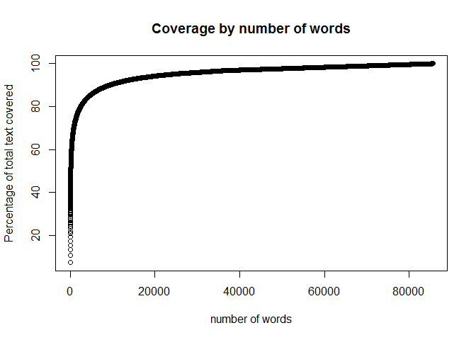

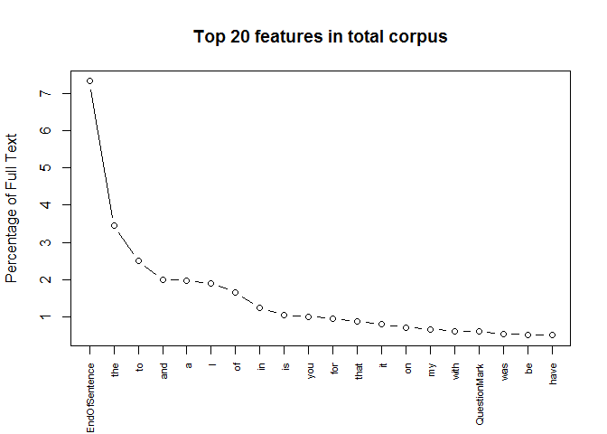

Now we’re going to have a look to the 2-grams. The number of identical 2-grams in the dataset is:

```
## [1] 610397
```

So there are over 600.000 unique 2-grams in the dataset. That is a lot more than the 1-grams (words). How many 2-grams do we need to cover 50% of all the 2-grams in the data, and how many for 80%?

```
## [1] 26675
```

```
## [1] 304426
```

We see here that there are also a lot more 2-grams needed to have a coverage of 50% or 80%. The plot also shows this.

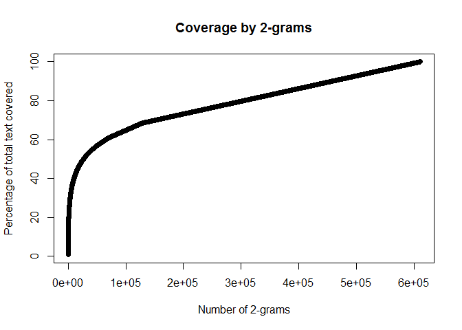

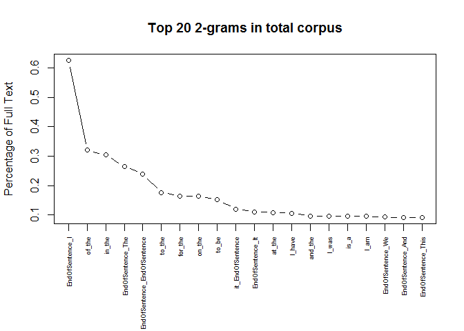

We have 1.2 milion 3-grams in the dataset and we see that there are a lot of low counts. Therefore a lot of 3-grams are necessary to get a coverage of 50% or 80%. See also the plot below.

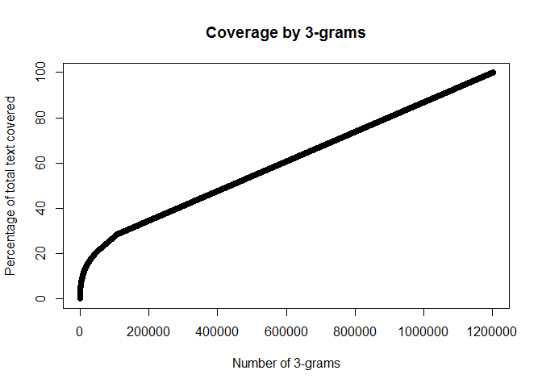

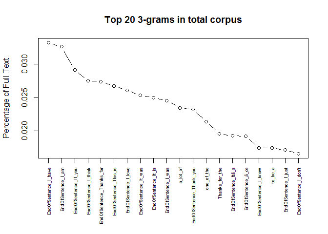

For the 4-grams the situation is even more sparse. There is not enough data to have enough coverage. So in an application, smoothing is absolutely necessary to deal with unseen n-grams.

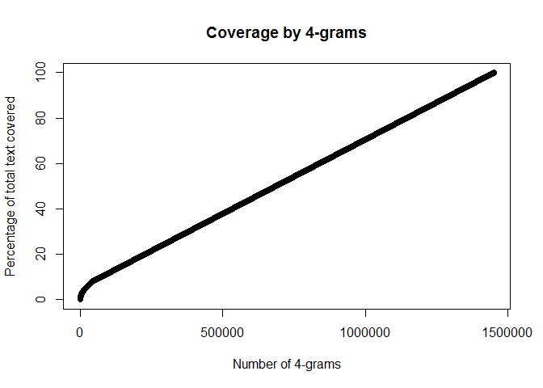

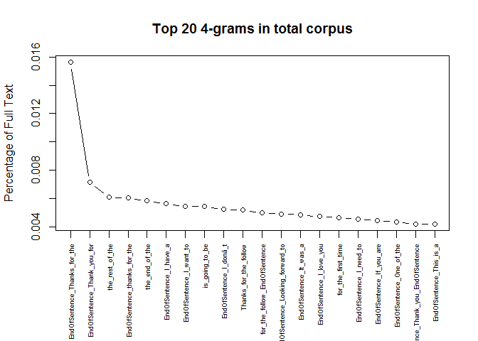

## Issues in the data

The data is obtained by internet scraping. There are a lot of errors in the datasets: characters that are not recognized, misspelled words, etc. Because there is no use to predict non-existing words I choose to remove all words and n-grams that are not english words. For that I use an english wordlist and check all the occurring words in the dataset. This wordlist is my vocabulary list.

## Further thoughts about the modeling steps

I’m building a n-gram model that predicts the next word following the previous n-1 words. I’m looking for the word that has the highest probability to follow these n-1 words. I use the constructed training set to train the model. To choose the order of the model (n) I calculate the perplexity for each model through cross-validation. The perplexity measures the quality of the model, the lower the perplexity the higher the probabilities in the cross-validation set. For higher order n, the perplexity will get lower. But the processing time will alse increase, so we need to balance a good quality with fast processing.

We saw in the plots that data sparsity is an issue here, the coverage is not high enough to see all the possible n-grams in the training set. We need to find a solution for n-grams that are not in the training set, the unseen words. In order to do this, I need to do smoothing. In the smoothing I’ll use lower order n-grams when there is not enough information about the higher order n-gram.